# Will per-site phyloP work on your tree?

Per-site phyloP asks, base by base, whether a site is evolving slower than neutral. Whether it can find *anything* depends on your tree — and on some trees it cannot call a single site, no matter how conserved. Here is why, and how to tell in advance.

## The test, and the catch

phyloP scores every column of an alignment for conservation. Genome-wide that is millions of tests, so the scores are corrected for multiple comparisons: to be called conserved, a site's score must clear a **bar that rises with the number of sites you test** — more tests, higher bar.

The catch is that there is also a **ceiling** on how high any per-site score can possibly go, and that ceiling is set by your tree. If the ceiling sits below the bar, **nothing passes** — phyloP returns roughly zero conserved sites. Not because nothing is conserved, but because the test cannot resolve conservation on that tree. It is a power problem, not a biology result.

## Why there is a ceiling

The strongest evidence a site could ever show is **perfect conservation** — the same base in every species. How surprising is that under neutral evolution? It is essentially the chance that neutral evolution produced **zero substitutions** anywhere across the whole tree.

So the ceiling is really a substitution count. A **deeper tree** — more total branch length, i.e. more evolutionary time summed over all branches — means neutral evolution would be *expected* to make more substitutions, which makes seeing none more surprising, which makes a stronger score. The ceiling climbs with total tree depth.

## Two ways to run out of power

The climb doesn't go on forever. There are two distinct ways a tree can leave phyloP underpowered, and your ceiling is set by whichever one binds first:

- **Too little depth (depth-limited).** If the tree is shallow — little total branch length — even perfect conservation isn't surprising enough to clear the bar. *Fix:* more or deeper branches (more evolutionary time / more divergent taxa), or test fewer sites.
- **Too few species (taxon-limited).** Past a point, branches *saturate*: so much time has passed that bases randomize, and extra depth stops adding information. Then only **more species** can raise the ceiling. With few species there is a hard wall that no amount of tree depth can beat.

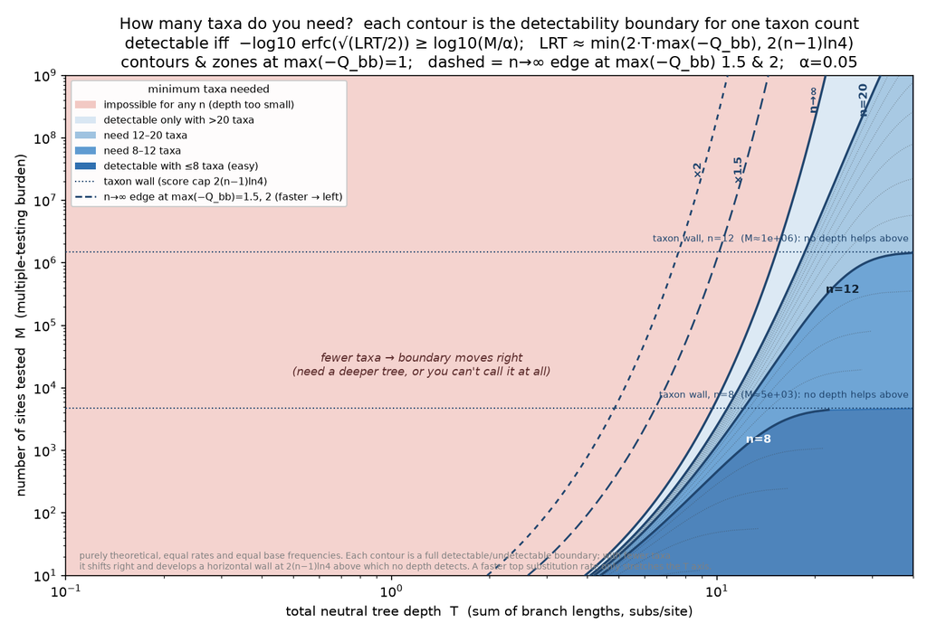

The two limits as a map. Horizontal axis = total tree depth \(T\) (sum of branch lengths); vertical = number of sites tested (the multiple-testing burden); each solid contour is the detectable/undetectable boundary for one species count. Read across at your number of sites: with fewer species the boundary sits farther right (you need a deeper tree), and eventually flattens into a horizontal *wall* — above it, no amount of depth makes a call. The dashed lines show that a faster-evolving model (a larger substitution rate) slides the boundary left — you need less depth — but cannot move the walls. (Theoretical; solid contours drawn for equal substitution rates and equal base frequencies.)

## What to do

- **Deep, taxon-rich trees** (e.g. the 241-mammal alignment): per-site phyloP works well — you're far inside the detectable region.
- **Shallow or few-taxon trees** (a handful of closely related genomes): per-site phyloP will find little or nothing. Reach for **element-based conservation** instead — phastCons / conserved elements pool signal across neighboring bases and can clear the bar where single sites can't — or add more divergent taxa / deeper outgroups.
- The pipeline checks this for you: a **pre-flight power gate** computes the ceiling from your fitted neutral model and skips the expensive per-site phyloP scan when the ceiling can't clear the bar (rather than running it just to return nothing).

**In one line:** a conserved site is callable only when \(-\log_{10}\operatorname{erfc}\!\big(\sqrt{\mathrm{LRT}_{\max}/2}\big)\ge\log_{10}(M/\alpha)\) — the tree's best-possible score clears the correction for \(M\) tests at level \(\alpha\); deeper trees and more species raise the left side.

Want the derivation — where the ceiling and the two limits come from, step by step? See the full detectability math.